# Projet Pratique : Titanic Survival Prediction

**Auteur : Kofivi YENA**

## Introduction

Après avoir appris l'optimisation d'une pipeline d'apprentissage automatique, nous passons à la pratique avec un jeu de données du monde réel.

Vous allons utiliser la validation croisée et une recherche sur une grille d'hyperparamètres pour optimiser une pipeline d'apprentissage automatique.

Nous utiliserons le jeu de données Titanic Survival Dataset pour construire un modèle de classification capable de prédire si un passager a survécu au naufrage du Titanic, en fonction des caractéristiques de chaque passager dans le jeu de données.

Nous commencerons par construire un Random Forest Classifier, puis nous modifierons notre pipeline pour utiliser un estimateur de régression logistique à la place. Nous évaluerons et comparerons nos résultats.

## Objectifs

Ce projet consiste à :

- Utiliser scikit-learn pour construire un modèle afin de résoudre un problème de classification
- Mettre en œuvre un pipeline combinant les étapes de prétraitement avec un modèle d'apprentissage automatique
- Interpréter les résultats de notre modélisation
- Mettre à jour notre pipeline avec un modèle d'apprentissage automatique différent
- Comparer les performances de nos classificateurs

## Chargeons les packages nécessaires

```python
import pandas as pd
import numpy as np
import matplotlib.pyplot as plt
import seaborn as sns
from sklearn.model_selection import train_test_split, GridSearchCV, cross_val_score, StratifiedKFold
from sklearn.ensemble import RandomForestClassifier
from sklearn.linear_model import LogisticRegression
from sklearn.impute import SimpleImputer
from sklearn.preprocessing import StandardScaler, OneHotEncoder
from sklearn.compose import ColumnTransformer
from sklearn.pipeline import Pipeline
from sklearn.neighbors import KNeighborsClassifier
from sklearn.datasets import load_iris
from sklearn.decomposition import PCA
from sklearn.metrics import confusion_matrix, classification_report, ConfusionMatrixDisplay
```

Nous allons travailler avec le jeu de données des passagers du Titanic pour construire un modèle de classification permettant de prédire si un passager a survécu au naufrage du Titanic. Voici le dictionnaire des données :

| Variable | Definition |
| --- | --- |
| survived | survived? 0 = No, 1 = yes |
| pclass | Ticket class (int) |
| sex | sex |
| age | age in years |
| sibsp | # of siblings / spouses aboard the Titanic |
| parch | # of parents / children aboard the Titanic |
| fare | Passenger fare |
| embarked | Port of Embarkation |
| class | Ticket class (obj) |
| who | man, woman, or child |
| adult_male | True/False |
| alive | yes/no |
| alone | yes/no |

# Chargeons le dataset en utilisant seaborn

```python
titanic  = sns.load_dataset('titanic')
titanic.head()
```

|  | survived | pclass | sex | age | sibsp | parch | fare | embarked | class | who | adult_male | deck | embark_town | alive | alone |
| --- | --- | --- | --- | --- | --- | --- | --- | --- | --- | --- | --- | --- | --- | --- | --- |
| 0 | 0 | 3 | male | 22.0 | 1 | 0 | 7.2500 | S | Third | man | True | NaN | Southampton | no | False |
| 1 | 1 | 1 | female | 38.0 | 1 | 0 | 71.2833 | C | First | woman | False | C | Cherbourg | yes | False |
| 2 | 1 | 3 | female | 26.0 | 0 | 0 | 7.9250 | S | Third | woman | False | NaN | Southampton | yes | True |
| 3 | 1 | 1 | female | 35.0 | 1 | 0 | 53.1000 | S | First | woman | False | C | Southampton | yes | False |
| 4 | 0 | 3 | male | 35.0 | 0 | 0 | 8.0500 | S | Third | man | True | NaN | Southampton | no | True |

# Sélectionner les variables explicatives pertinentes (features) et la variable cible (target)

```python
titanic.count()
```

[output not shown]

**Fonctionnalités à supprimer**

La variable deck contient de nombreuses valeurs manquantes, nous allons donc la supprimer. Age présente également plusieurs valeurs manquantes. Bien qu'elles puissent être utiles, les variables embarked et embark_town ne semblent pas pertinentes, nous allons donc les supprimer aussi. La signification de alive n'est pas claire, nous allons donc l'ignorer.

**Variable cible**

La variable survived est notre variable cible à prédire.

```python
features = ['pclass', 'sex', 'age', 'sibsp', 'parch', 'fare', 'class', 'who', 'adult_male', 'alone']
target = 'survived'

X = titanic[features]
y = titanic[target]
```

1. La Répartition des survivants

```python
print(y.value_counts())
```

```
survived
0    549
1    342
Name: count, dtype: int64
```

Environ 38 % des passagers du jeu de données ont survécu. En raison de ce léger déséquilibre, nous devrions stratifier les données lors de la séparation des données (train/test) et pour la validation croisée.

1. Diviser les données en ensembles d'entraînement et de test

```python
X_train, X_test, y_train, y_test = train_test_split(X, y, test_size=0.2, random_state=42, stratify=y)
```

- Définir des transformateurs de prétraitement pour les caractéristiques numériques et catégorielles
- Détecter automatiquement les colonnes numériques et catégorielles et les attribuer respectivement aux caractéristiques numériques et catégorielles

```python
numerical_features = X_train.select_dtypes(include=['number']).columns.tolist()
categorical_features = X_train.select_dtypes(include=['object', 'category']).columns.tolist()
```

Définir des pipelines de prétraitement distincts pour chaque type de caractéristique

```python
numerical_transformer = Pipeline(steps=[
    ('imputer', SimpleImputer(strategy='median')),
    ('scaler', StandardScaler())
])

categorical_transformer = Pipeline(steps=[
    ('imputer', SimpleImputer(strategy='most_frequent')),
    ('onehot', OneHotEncoder(handle_unknown='ignore'))
])
```

# Combiner les transformateurs en un seul transformateur de colonnes

Nous utiliserons l'estimateur "column transformer" de sklearn pour transformer séparément les caractéristiques, puis concaténer la sortie en un seul espace de caractéristiques, prêt à être utilisé comme entrée pour un estimateur de machine learning.

```python
preprocessor = ColumnTransformer(
    transformers=[
        ('num', numerical_transformer, numerical_features),
        ('cat', categorical_transformer, categorical_features)
    ])
```

# Créer un pipeline de modélisation

Complétons maintenant le pipeline de modélisation en combinant le prétraitement avec un classificateur Random Forest.

```python
pipeline = Pipeline(steps=[
    ('preprocessor', preprocessor),
    ('classifier', RandomForestClassifier(random_state=42))
])
```

# Définir une grille de paramètres

Nous utiliserons cette grille dans une recherche par validation croisée pour optimiser le modèle.

```python
param_grid = {
    'classifier__n_estimators': [50, 100],
    'classifier__max_depth': [None, 10, 20],
    'classifier__min_samples_split': [2, 5]
}
```

- Effectuer une recherche par validation croisée sur grille et ajuster le meilleur modèle aux données d'entraînement.

```python
# Cross-validation method
cv = StratifiedKFold(n_splits=5, shuffle=True)
```

# Entraîner le papiline de modèle

```python
model = GridSearchCV(estimator=pipeline, param_grid=param_grid, cv=cv, scoring='accuracy', verbose=2)
model.fit(X_train, y_train)
```

[output not shown]

[output cut: 21 more lines]

```
GridSearchCV(cv=StratifiedKFold(n_splits=5, random_state=None, shuffle=True),
             estimator=Pipeline(steps=[('preprocessor',
                                        ColumnTransformer(transformers=[('num',
                                                                         Pipeline(steps=[('imputer',
                                                                                          SimpleImputer(strategy='median')),
                                                                                         ('scaler',
                                                                                          StandardScaler())]),
                                                                         ['pclass',
                                                                          'age',
                                                                          'sibsp',
                                                                          'parch',
                                                                          'fare']),
                                                                        ('cat',
                                                                         Pipeline(steps=[('imputer',
                                                                                          SimpleImputer(strategy='most_frequent')),
                                                                                         ('onehot',
                                                                                          OneHotEncoder(handle_unknown='ignore'))]),
                                                                         ['sex',
                                                                          'class',
                                                                          'who'])])),
                                       ('classifier',
                                        RandomForestClassifier(random_state=42))]),
             param_grid={'classifier__max_depth': [None, 10, 20],
                         'classifier__min_samples_split': [2, 5],
                         'classifier__n_estimators': [50, 100]},
             scoring='accuracy', verbose=2)
```

# Obtenir les prédictions du modèle à partir de l'estimateur de la recherche sur grille sur les données non vues

1. Affichons également un rapport de classification.

```python
y_pred = model.predict(X_test)
print(classification_report(y_test, y_pred))
```

```
              precision    recall  f1-score   support

           0       0.83      0.88      0.85       110
           1       0.79      0.71      0.75        69

    accuracy                           0.82       179
   macro avg       0.81      0.80      0.80       179
weighted avg       0.81      0.82      0.81       179
```

1. La matrice de confusion

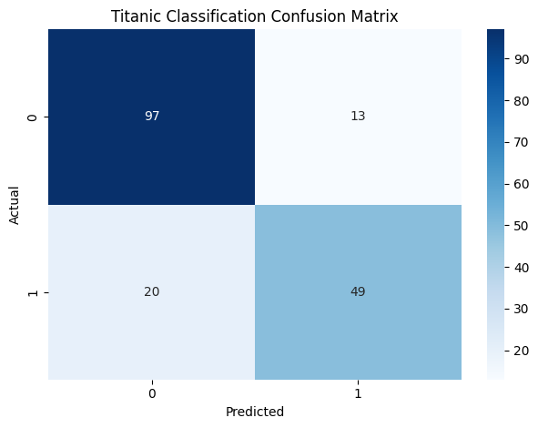

```python
# Générons la matrice de confusion
conf_matrix = confusion_matrix(y_test, y_pred)

plt.figure()
sns.heatmap(conf_matrix, annot=True, cmap='Blues', fmt='d')

# titre et label
plt.title('Titanic Classification Confusion Matrix')
plt.xlabel('Predicted')
plt.ylabel('Actual')

# Affichons le graphique
plt.tight_layout()
plt.show()
```

# Obtenons les importances des caractéristiques de notre modèle global.

Tout d'abord, pour obtenir les importances des caractéristiques catégorielles, nous devons remonter à travers le pipeline de modélisation afin d'associer les importances des caractéristiques aux variables encodées en one-hot, qui ont été transformées à partir des caractéristiques catégorielles d'origine.

Nous n'avons pas besoin de remonter le pipeline pour les caractéristiques numériques, car nous ne les avons pas transformées en de nouvelles variables.

Rappelons que nous avons converti les caractéristiques catégorielles en caractéristiques encodées en one-hot à l'aide du transformateur de colonnes « cat ».

```python
model.best_estimator_['preprocessor'].named_transformers_['cat'].named_steps['onehot'].get_feature_names_out(categorical_features)
```

```
array(['sex_female', 'sex_male', 'class_First', 'class_Second',
       'class_Third', 'who_child', 'who_man', 'who_woman'], dtype=object)
```

Remarquons comment les caractéristiques encodées en one-hot sont nommées : par exemple, la variable sex a été divisée en deux caractéristiques booléennes indiquant si le sexe est masculin ou féminin.

Super ! Maintenant, récupérons toutes les importances des caractéristiques et associons-les aux noms des caractéristiques transformées.

```python
feature_importances = model.best_estimator_['classifier'].feature_importances_

# Combine the numerical and one-hot encoded categorical feature names
feature_names = numerical_features + list(model.best_estimator_['preprocessor']
                                        .named_transformers_['cat']
                                        .named_steps['onehot']
                                        .get_feature_names_out(categorical_features))
```

Affichons les importances des caractéristiques sous forme de graphique en barres

Définissons un DataFrame des importances des caractéristiques, puis visualisons-le

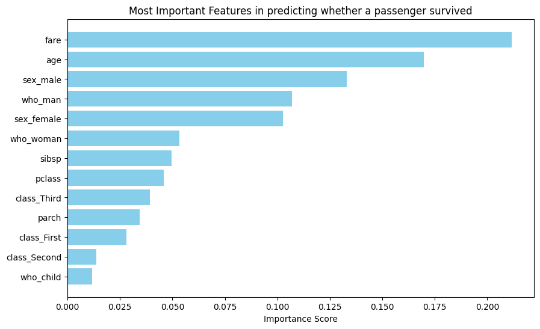

```
Test set accuracy: 81.56%
```

```python
importance_df = pd.DataFrame({'Feature': feature_names,
                              'Importance': feature_importances
                             }).sort_values(by='Importance', ascending=False)

# Plotting
plt.figure(figsize=(10, 6))
plt.barh(importance_df['Feature'], importance_df['Importance'], color='skyblue')
plt.gca().invert_yaxis()
plt.title('Most Important Features in predicting whether a passenger survived')
plt.xlabel('Importance Score')
plt.show()

# Print test score
test_score = model.score(X_test, y_test)
print(f"\nTest set accuracy: {test_score:.2%}")
```

**Commentaire** : La précision sur l’ensemble de test est plutôt satisfaisante. Cependant, en ce qui concerne les importances des caractéristiques, il est essentiel de comprendre qu’il existe probablement une forte dépendance entre ces variables. Une approche de modélisation plus détaillée, incluant une analyse de corrélation, est nécessaire pour tirer des conclusions fiables.

Par exemple, il ne fait aucun doute que les variables **age**, **sex_male** et **who_man** partagent une quantité significative d’informations.

# Essayons un autre modèle

En pratique, il est recommandé de tester différents modèles et même de revoir l’analyse des données pour améliorer les performances du modèle. Il pourrait être utile de créer de nouvelles caractéristiques ou d’imputer les valeurs manquantes afin d’exploiter un plus grand volume de données.

Grâce à la classe Pipeline de Scikit-learn, cette tâche est simple et rapide. Mettons à jour le pipeline et la grille de paramètres afin d’entraîner un modèle de régression logistique et comparer ses performances avec celles du modèle précédent.

```python
# Remplaçons RandomForestClassifier avec LogisticRegression
pipeline.set_params(classifier=LogisticRegression(random_state=42))

# Mettons à jour le modèle estimator pour utiliser un nouveau pipeline
model.estimator = pipeline

# Défissons une grille avec les paramètres de la Regrèssion logistique
param_grid = {
    # 'classifier__n_estimators': [50, 100],
    # 'classifier__max_depth': [None, 10, 20],
    # 'classifier__min_samples_split': [2, 5],
    'classifier__solver' : ['liblinear'],
    'classifier__penalty': ['l1', 'l2'],
    'classifier__class_weight' : [None, 'balanced']
}

model.param_grid = param_grid

# Model fit
model.fit(X_train, y_train)

# Prédictions
y_pred = model.predict(X_test)
```

```
Fitting 5 folds for each of 4 candidates, totalling 20 fits
[CV] END classifier__class_weight=None, classifier__penalty=l1, classifier__solver=liblinear; total time=   0.0s
[CV] END classifier__class_weight=None, classifier__penalty=l1, classifier__solver=liblinear; total time=   0.0s
[CV] END classifier__class_weight=None, classifier__penalty=l1, classifier__solver=liblinear; total time=   0.0s
[CV] END classifier__class_weight=None, classifier__penalty=l1, classifier__solver=liblinear; total time=   0.0s
[CV] END classifier__class_weight=None, classifier__penalty=l1, classifier__solver=liblinear; total time=   0.0s
[CV] END classifier__class_weight=None, classifier__penalty=l2, classifier__solver=liblinear; total time=   0.0s
[CV] END classifier__class_weight=None, classifier__penalty=l2, classifier__solver=liblinear; total time=   0.0s
[CV] END classifier__class_weight=None, classifier__penalty=l2, classifier__solver=liblinear; total time=   0.0s
[CV] END classifier__class_weight=None, classifier__penalty=l2, classifier__solver=liblinear; total time=   0.0s
[CV] END classifier__class_weight=None, classifier__penalty=l2, classifier__solver=liblinear; total time=   0.0s
[CV] END classifier__class_weight=balanced, classifier__penalty=l1, classifier__solver=liblinear; total time=   0.0s
[CV] END classifier__class_weight=balanced, classifier__penalty=l1, classifier__solver=liblinear; total time=   0.0s
[CV] END classifier__class_weight=balanced, classifier__penalty=l1, classifier__solver=liblinear; total time=   0.0s
[CV] END classifier__class_weight=balanced, classifier__penalty=l1, classifier__solver=liblinear; total time=   0.0s
[CV] END classifier__class_weight=balanced, classifier__penalty=l1, classifier__solver=liblinear; total time=   0.0s
[CV] END classifier__class_weight=balanced, classifier__penalty=l2, classifier__solver=liblinear; total time=   0.0s
[CV] END classifier__class_weight=balanced, classifier__penalty=l2, classifier__solver=liblinear; total time=   0.0s
[CV] END classifier__class_weight=balanced, classifier__penalty=l2, classifier__solver=liblinear; total time=   0.0s
[CV] END classifier__class_weight=balanced, classifier__penalty=l2, classifier__solver=liblinear; total time=   0.0s
[CV] END classifier__class_weight=balanced, classifier__penalty=l2, classifier__solver=liblinear; total time=   0.0s
```

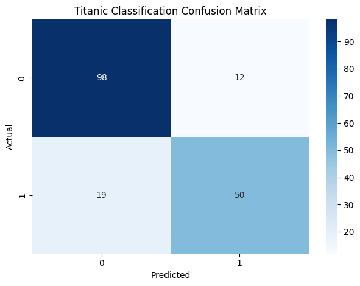

```python
conf_matrix = confusion_matrix(y_test, y_pred)

plt.figure()
sns.heatmap(conf_matrix, annot=True, cmap='Blues', fmt='d')

plt.title('Titanic Classification Confusion Matrix')
plt.xlabel('Predicted')
plt.ylabel('Actual')

plt.tight_layout()
plt.show()
```

**Commentaire** : encore une fois, les résultats montrent une légère amélioration, avec un vrai positif et un vrai négatif supplémentaires.

- Extraire les coefficients des caractéristiques du modèle de régression logistique et afficher leur magnitude sous forme de graphique en barres.

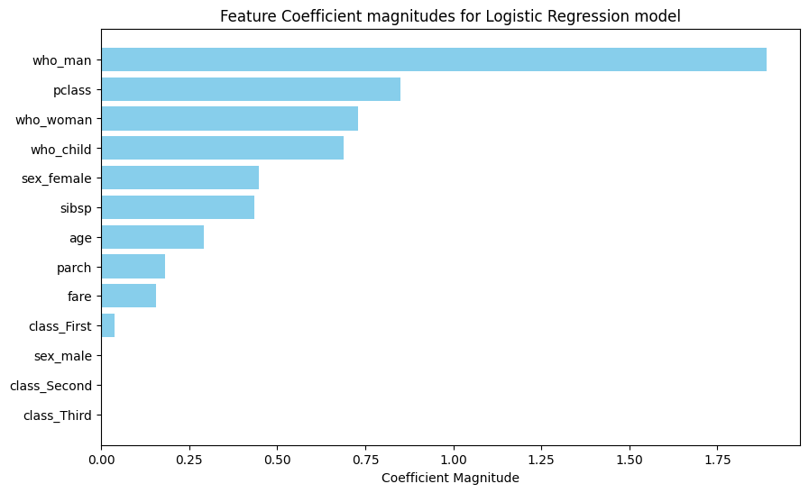

```
Test set accuracy: 82.68%
```

```python
coefficients = model.best_estimator_.named_steps['classifier'].coef_[0]

# Combine numerical and categorical feature names
numerical_feature_names = numerical_features
categorical_feature_names = (model.best_estimator_.named_steps['preprocessor']
                                     .named_transformers_['cat']
                                     .named_steps['onehot']
                                     .get_feature_names_out(categorical_features)
                            )
feature_names = numerical_feature_names + list(categorical_feature_names)


# Créons un DataFrame pour les coefficients
importance_df = pd.DataFrame({
    'Feature': feature_names,
    'Coefficient': coefficients
}).sort_values(by='Coefficient', ascending=False, key=abs)  # Sort by absolute values

# Plot
plt.figure(figsize=(10, 6))
plt.barh(importance_df['Feature'], importance_df['Coefficient'].abs(), color='skyblue')
plt.gca().invert_yaxis()
plt.title('Feature Coefficient magnitudes for Logistic Regression model')
plt.xlabel('Coefficient Magnitude')
plt.show()

# Affichons le score
test_score = model.best_estimator_.score(X_test, y_test)
print(f"\nTest set accuracy: {test_score:.2%}")
```

**Conclusion** : Bien que les performances des deux modèles soient pratiquement identiques, les caractéristiques importantes pour chacun des modèles sont très différentes. Cela suggère qu'il reste encore du travail pour mieux comprendre les véritables importances des caractéristiques. Comme mentionné précédemment, il est crucial de réaliser qu'il y a très probablement de nombreuses dépendances entre ces variables, et une approche de modélisation plus détaillée, incluant une analyse de corrélation, est nécessaire pour tirer des conclusions appropriées.

Par exemple, il existe une information significative entre les variables who_man, who_woman et who_child, car si une personne n'est ni un homme ni une femme, alors elle doit être un enfant.